# Lab 05

Jack Reddan

10/14/2021

# Lab 05: Data Visualization

## Library loading

```r
library(ggplot2)
library(gapminder)
library(dplyr)
library(plotly)
library(patchwork)
```

## Data exploration

Examine the *cars* dataset with the “head” function.

```r
head(cars)
```

```
##   speed dist
## 1     4    2
## 2     4   10
## 3     7    4
## 4     7   22
## 5     8   16
## 6     9   10
```

## Plotting the data

Graph stopping distance (ft) as a function of speed (mph) from the ‘cars’ dataset using ggplot2.

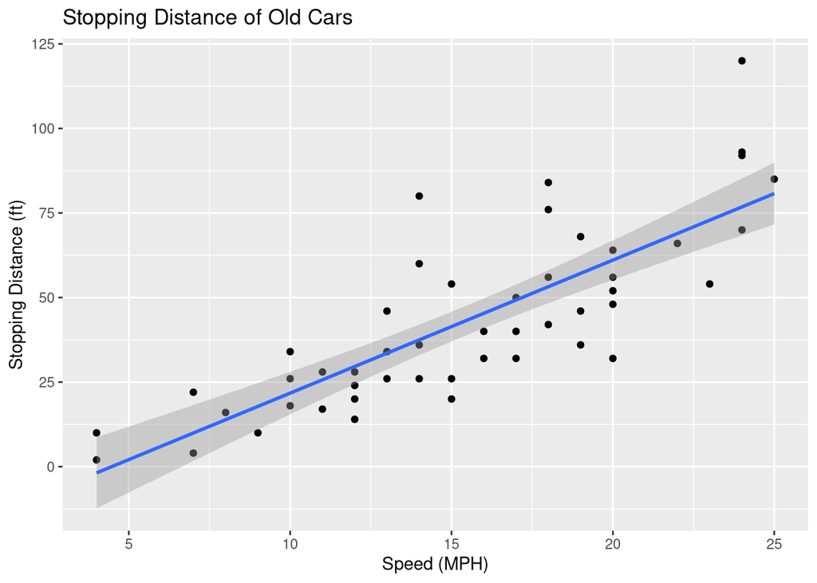

```r
ggplot(data = cars) +
  aes(x = speed, y = dist) +
  geom_point() +
  geom_smooth(formula = y ~ x,
              method = "lm") +
  labs(title = "Stopping Distance of Old Cars",
       x = "Speed (MPH)",
       y = "Stopping Distance (ft)")
```

Compare the ggplot2 graph to the graph generated from the plotting which comes from base R.

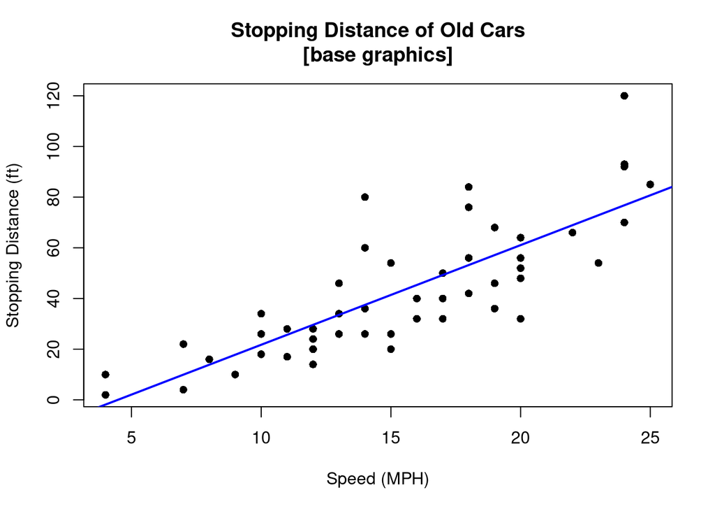

```r
# Base graphics translation
plot(x = cars$speed,
     y = cars$dist,
     pch = 16,
     main = "Stopping Distance of Old Cars\n[base graphics]",
     xlab = "Speed (MPH)",
     ylab = "Stopping Distance (ft)")
abline(lm(cars$dist ~ cars$speed),
       col = "blue",
       lwd = 2)
```

## Using the gene expression dataset

Reading in the gene expression tab-delimited data table as a dataframe and checking the table structure.

```r
# Loading in the genes data
url <- "https://bioboot.github.io/bimm143_S20/class-material/up_down_expression.txt"
genes <- read.delim(url)
head(genes)
```

```
##         Gene Condition1 Condition2      State
## 1      A4GNT -3.6808610 -3.4401355 unchanging
## 2       AAAS  4.5479580  4.3864126 unchanging
## 3      AASDH  3.7190695  3.4787276 unchanging
## 4       AATF  5.0784720  5.0151916 unchanging
## 5       AATK  0.4711421  0.5598642 unchanging
## 6 AB015752.4 -3.6808610 -3.5921390 unchanging
```

Exploring the data frame dimensions.

```r
# How many genes are in the dataframe
nrow(genes)
```

```
## [1] 5196
```

```r
# What and how many types of data were collected on each gene.
colnames(genes)
```

```
## [1] "Gene"       "Condition1" "Condition2" "State"
```

```r
ncol(genes)
```

```
## [1] 4
```

```r
# Summary of State values for each gene
table(genes$State)
```

```
##
##       down unchanging         up
##         72       4997        127
```

```r
# Calculate the percentage of genes which were labeled "up" for their state
round(table(genes$State)["up"]/nrow(genes)*100, 2)
```

```
##   up
## 2.44
```

Plotting the gene states for both treatment conditions and coloring each data point by its state value.

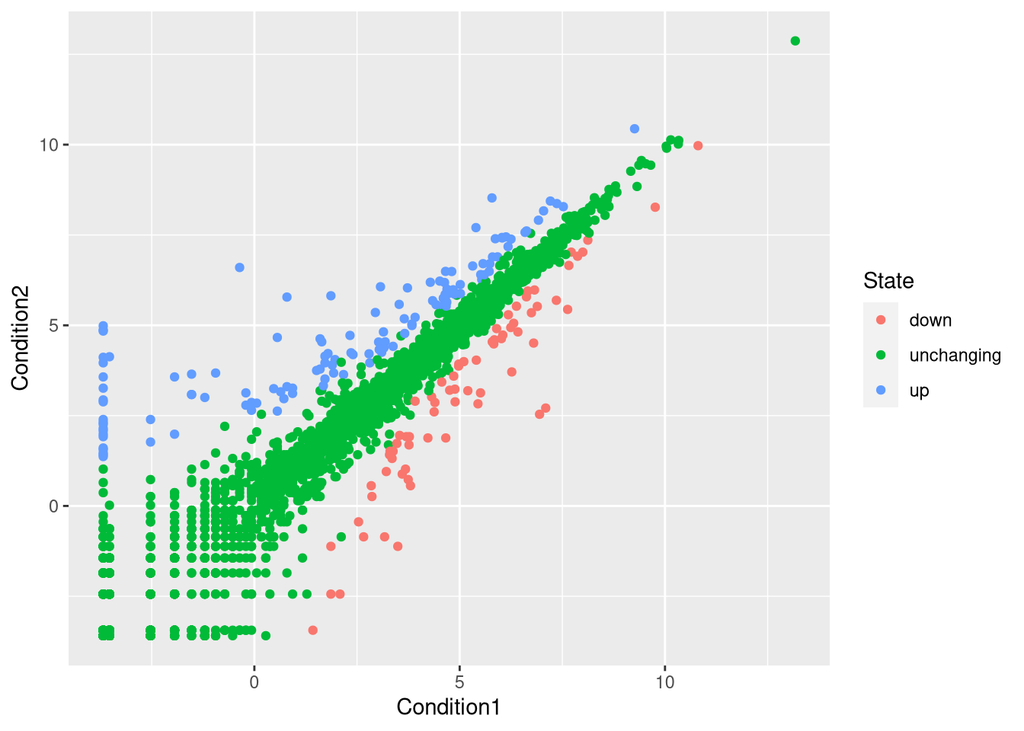

```r
p <- ggplot(data = genes) +
  aes(x = Condition1, y = Condition2,
      col = State) +
  geom_point()
p
```

Adding a unique color scheme to the plot.

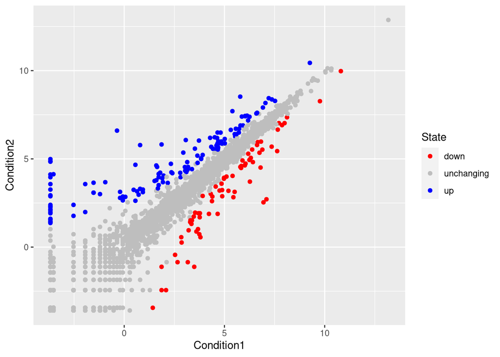

```r
p <- p +
  scale_color_manual(values = c("red", "gray", "blue"))
p
```

Adding a title and axis labels to the plot.

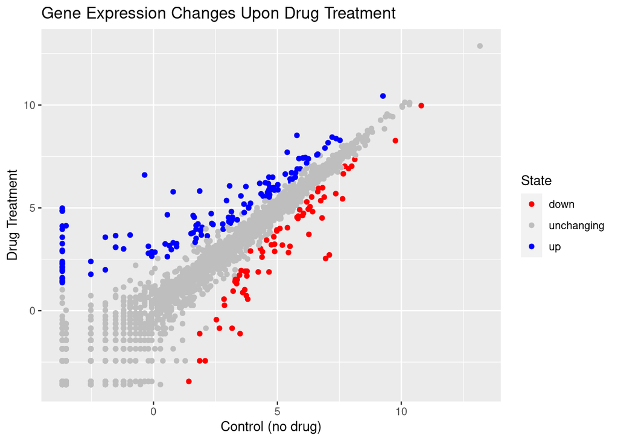

```r
p <- p +
  labs(title = "Gene Expression Changes Upon Drug Treatment",
       x = "Control (no drug)",
       y = "Drug Treatment")
p
```

## Using the gapminder dataset

Filter the gapminder dataframe for data associated with the year 2007.

```r
# gapminder dataset
gapminder_2007 <- gapminder %>% filter(year==2007)
```

Plot the gapminder data for life expectancy (lifeExp) across available years.

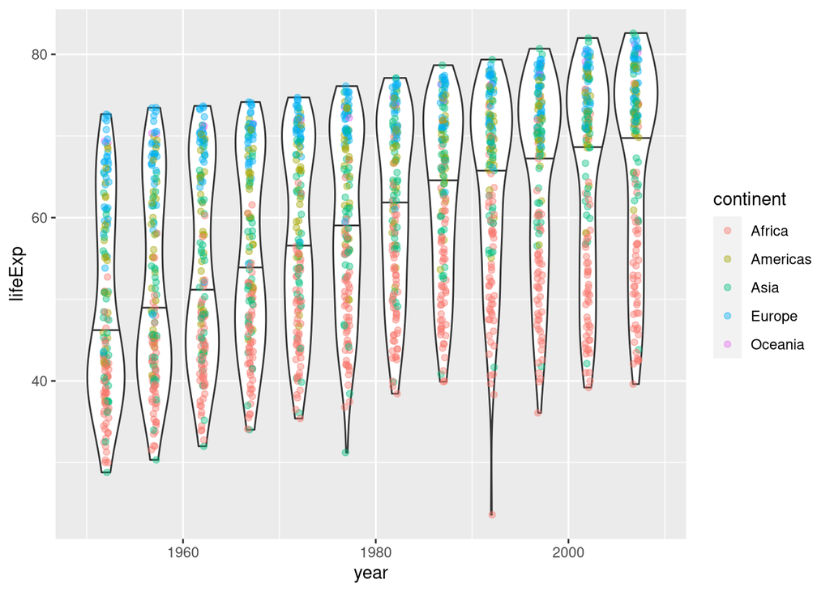

```r
# Use the geom_violin and geom_jitter layers to accurately view the distribution
# of data points
p <- ggplot(data = gapminder) +
  aes(x = year, y = lifeExp) +
  geom_violin(aes(group = year), draw_quantiles = c(0.5)) +
  geom_jitter(aes(col = continent), alpha = 0.4, width = 0.3)
p
```

Plot the 2007-subset of gapminder data for life expectancy (lifeExp) across the countrys’ associated GDP per capita.

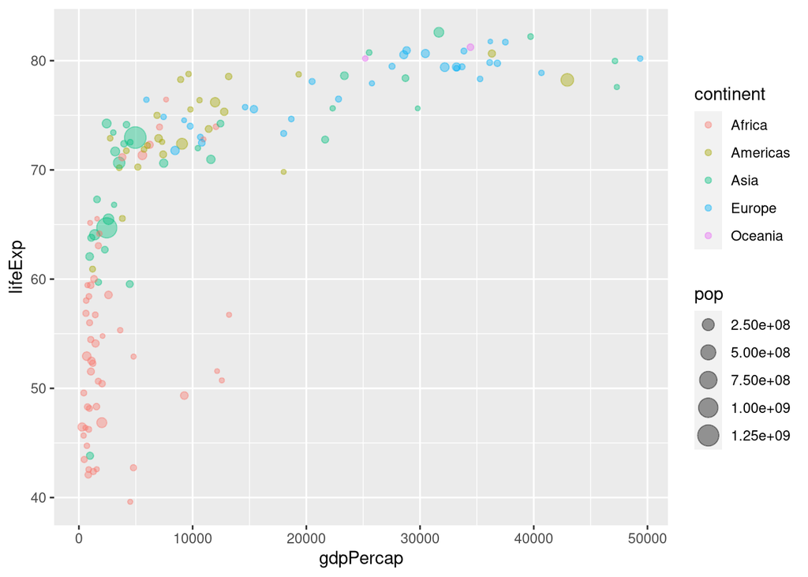

```r
p <- ggplot(data = gapminder_2007) +
  aes(x = gdpPercap, y = lifeExp, col = continent, size = pop) +
  geom_point(alpha=0.4)
p
```

Using a continuous variable for color.

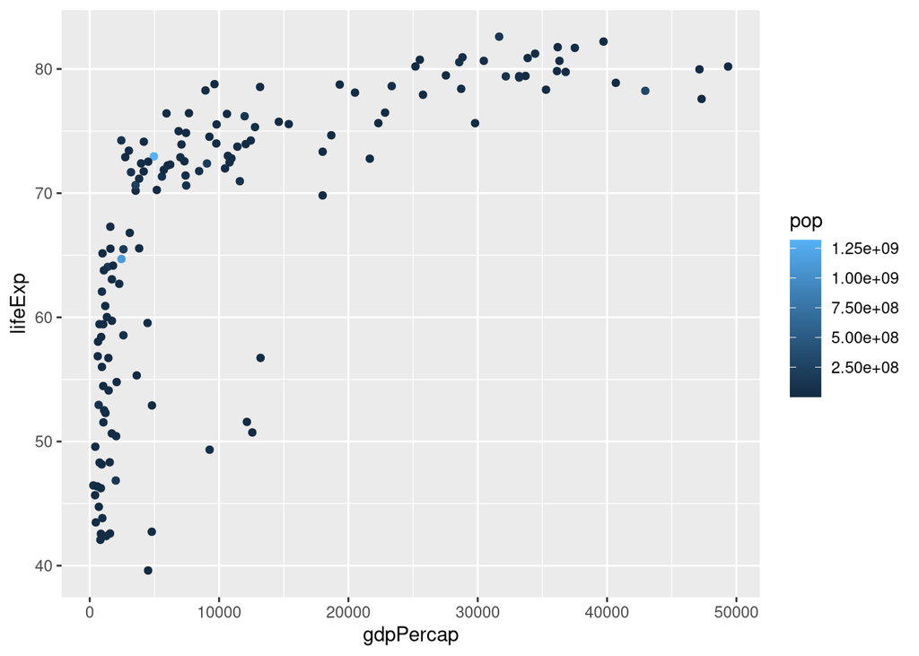

```r
# Gross example with population as color
q <- ggplot(data = gapminder_2007) +
  aes(x = gdpPercap, y = lifeExp, col = pop) +
  geom_point()
q
```

Scaling the size of the data points to better represent the differences in population sizes.

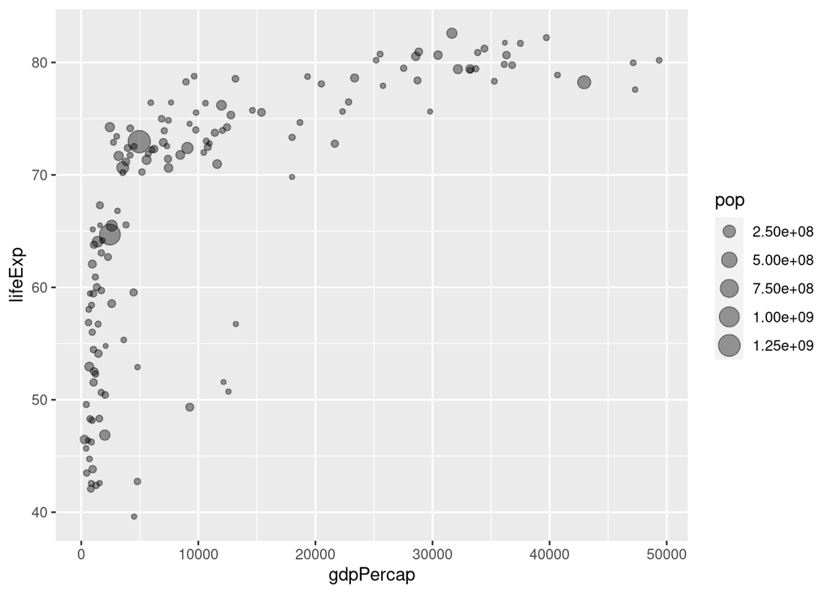

```r
# Adjusting point size
p <- ggplot(data = gapminder_2007) +
  aes(x = gdpPercap, y = lifeExp, size = pop) +
  geom_point(alpha=0.4)
p
```

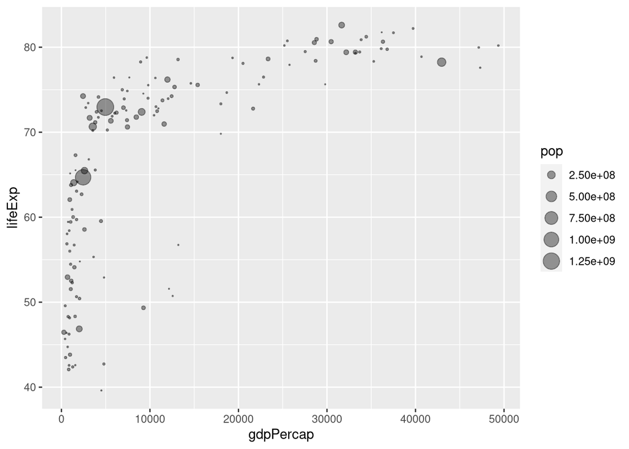

```r
p <- p + scale_size_area()
p
```

Filter the gapminder dataframe for data associated with the year 1957.

```r
# Exploring 1957 gapfinder data
gapminder_1957 <- gapminder %>% filter(year==1957)
```

Plot the 1957-subset of gapminder data for life expectancy (lifeExp) across the countrys’ associated GDP per capita.

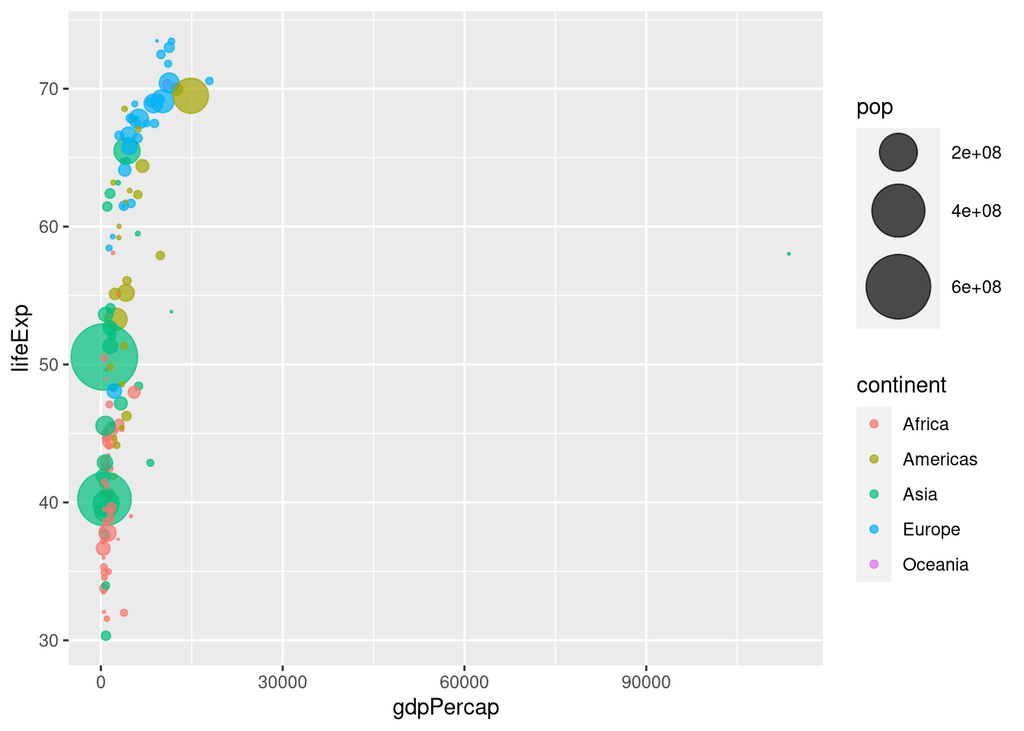

```r
p <- ggplot(data = gapminder_1957) +
  aes(x = gdpPercap, y = lifeExp, col = continent, size = pop) +
  geom_point(alpha=0.7) +
  scale_size_area(max_size = 15)
p
```

Filter the gapminder dataframe for data associated with the years 1957 and 2007.

```r
gapminder_1957_2007 <- gapminder %>% filter(year==1957 | year == 2007)
```

Plot the gapminder_1957_2007 data for life expectancy (lifeExp) across the countrys’ associated GDP per capita and facet wrap by the year.

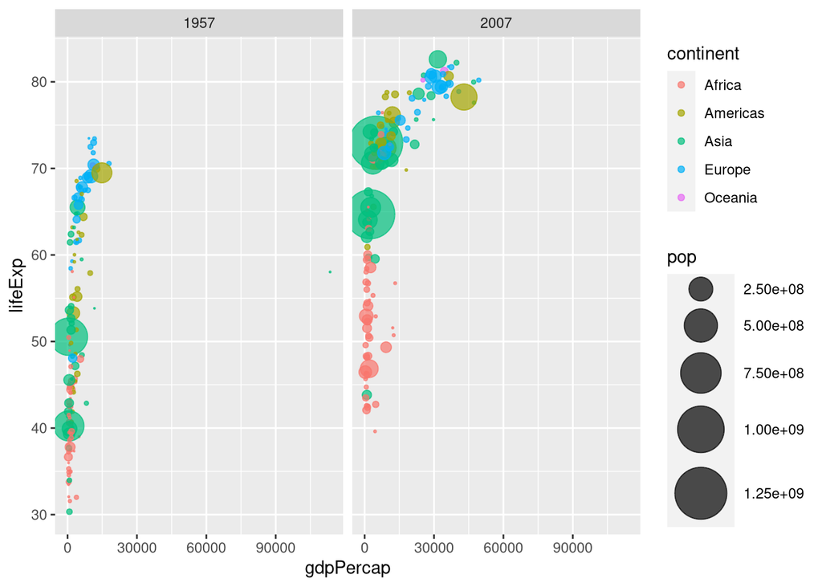

```r
p <- ggplot(data = gapminder_1957_2007) +
  aes(x = gdpPercap, y = lifeExp, col = continent, size = pop) +
  geom_point(alpha=0.7) +
  scale_size_area(max_size = 15) +
  facet_wrap(~year)
p
```

Filter the gapminder data for values from the year 2007 and select the top 5 countries with the highest population

```r
# Top 5 population in the gapminder data for the year 2007
gapminder_2007_top5 <- gapminder %>%
  filter(year == 2007) %>%
  arrange(desc(pop)) %>%
  top_n(5, pop)

# Check the tibble
gapminder_2007_top5
```

```
## # A tibble: 5 x 6
##   country       continent  year lifeExp        pop gdpPercap
##   <fct>         <fct>     <int>   <dbl>      <int>     <dbl>
## 1 China         Asia       2007    73.0 1318683096     4959.
## 2 India         Asia       2007    64.7 1110396331     2452.
## 3 United States Americas   2007    78.2  301139947    42952.
## 4 Indonesia     Asia       2007    70.6  223547000     3541.
## 5 Brazil        Americas   2007    72.4  190010647     9066.
```

Plot the population for each of the top five countries with the highest populations, and color by the country’s continent.

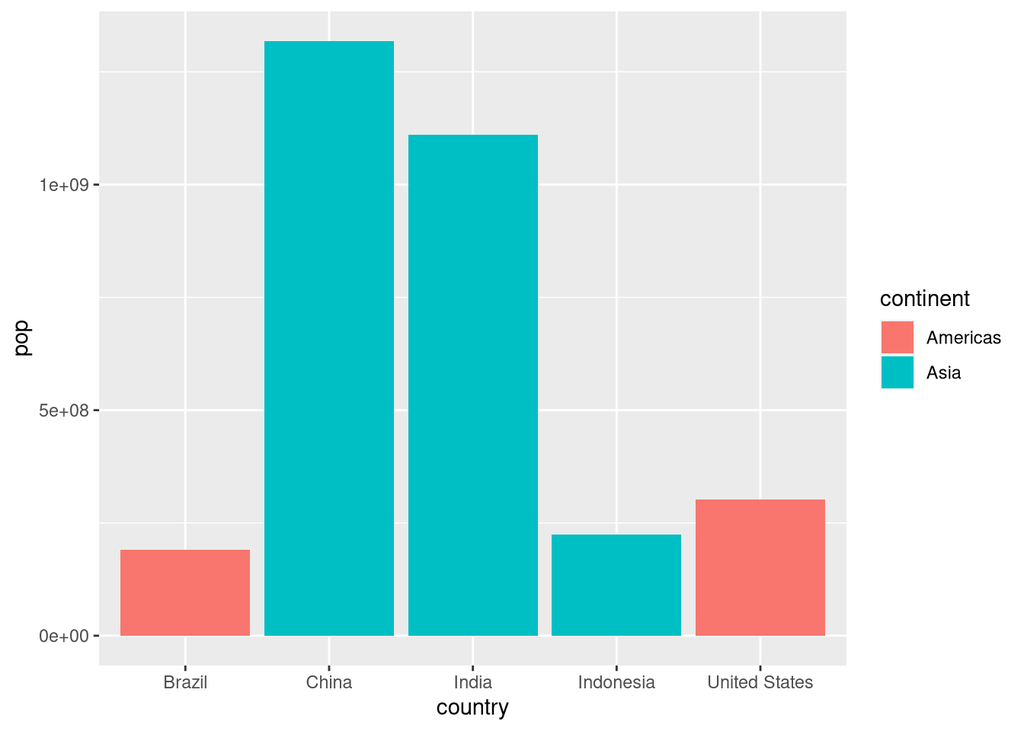

```r
ggplot(data = gapminder_2007_top5) +
  aes(x = country, y = pop, fill = continent) +
  geom_col()
```

Change the color mapping to the life expectancy of the country.

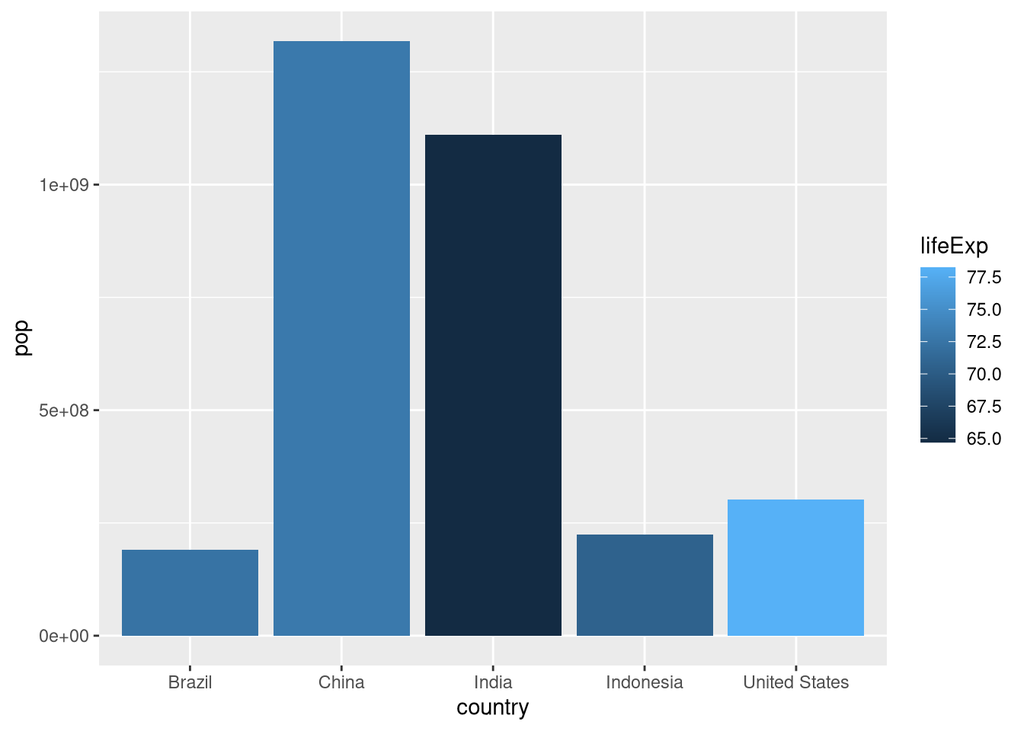

```r
ggplot(data = gapminder_2007_top5) +
  aes(x = country, y = pop, fill = lifeExp) +
  geom_col()
```

Change the order of the countries from highest to lowest and color by country.

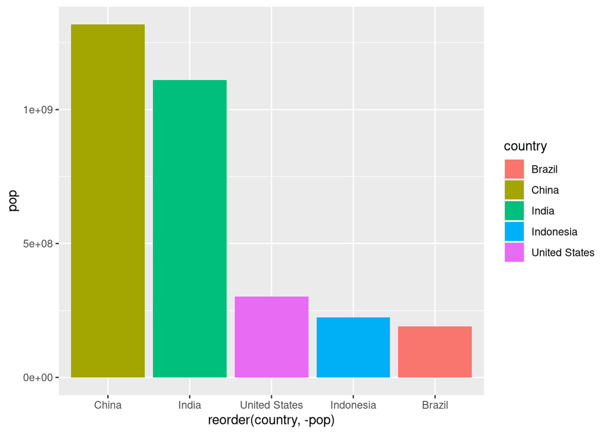

```r
ggplot(data = gapminder_2007_top5) +
  aes(x = reorder(country, -pop), y = pop, fill = country) +
  geom_col()
```

## Using the the USArrests dataset

Check the structure of the dataframe.

```r
head(USArrests)
```

```
##            Murder Assault UrbanPop Rape
## Alabama      13.2     236       58 21.2
## Alaska       10.0     263       48 44.5
## Arizona       8.1     294       80 31.0
## Arkansas      8.8     190       50 19.5
## California    9.0     276       91 40.6
## Colorado      7.9     204       78 38.7
```

Plot the murder arrests (per 100,000) for each state in the US, and flip the orientation of the plot 90 degrees.

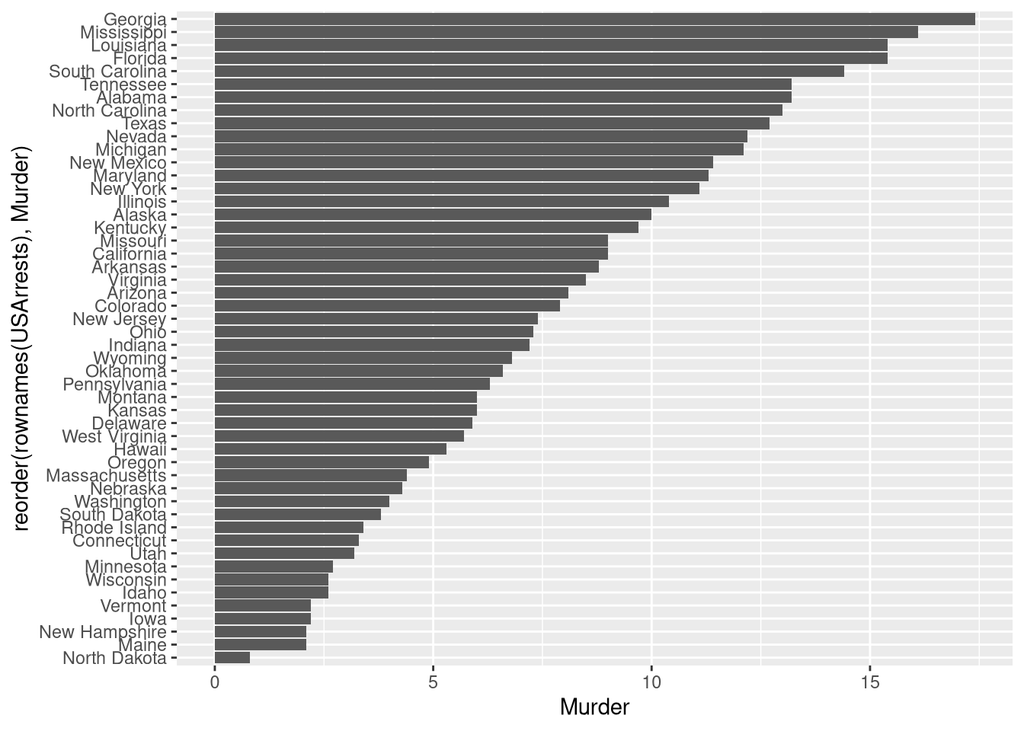

```r
ggplot(data = USArrests) +
  aes(x = reorder(rownames(USArrests), Murder), y = Murder) +
  coord_flip() +
  geom_col()
```

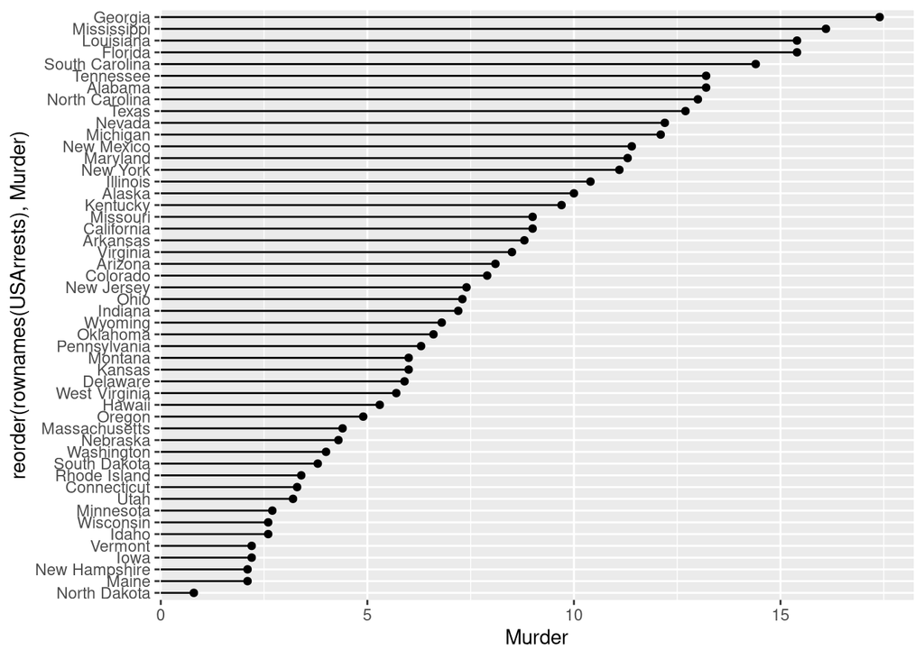

```r
ggplot(data = USArrests) +
  aes(x = reorder(rownames(USArrests), Murder), y = Murder) +
  geom_point() +
  geom_segment(x = rownames(USArrests),
               xend = rownames(USArrests),
               y = 0,
               yend = USArrests$Murder) +
  coord_flip()
```

## Combining plots

Assign example plots to variables.

```r
p1 <- ggplot(mtcars) + geom_point(aes(mpg, disp))
p2 <- ggplot(mtcars) + geom_boxplot(aes(gear, disp, group = gear))
p3 <- ggplot(mtcars) + geom_smooth(aes(disp, qsec))
p4 <- ggplot(mtcars) + geom_bar(aes(carb))
```

Combine the example plots with the *patchwork* library.

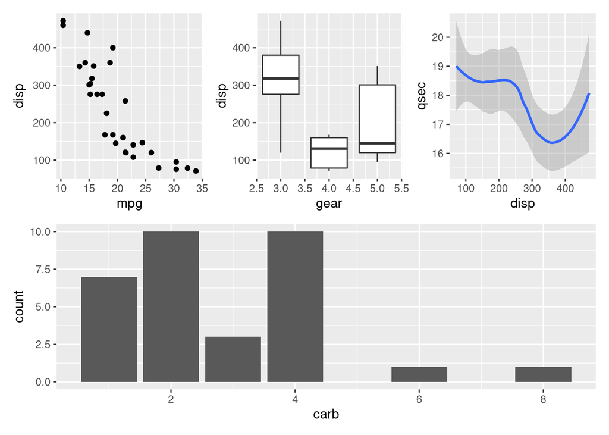

```r
(p1 | p2 | p3) /
      p4
```